# Tugas Besar IF2220 Probabilitas dan Statistika

### **Analisis Korelasi Kolom Non-Target dan Kolom Target**

**Kolom *Daerah***

```python
data1 = Gandum["Daerah"]
data2 = Gandum["Kelas"]
pearson_correlation_test(data1, data2)
```

```
Hipotesis nol ditolak karena nilai t masuk ke dalam critical region.
Nilai t-score yang dihasilkan adalah -16.857115233256664
P-Value yang dihasilkan untuk t-score tersebut adalah 8.925696449467643e-51
```

*Karena $H_{0}$ ditolak, maka berarti bahwa kolom `Daerah` memiliki korelasi dengan kolom `Kelas`. Karena pengujian dilakukan dengan menggunakan `Two-Tailed Test` dan nilai dari t-score masuk ke dalam daerah kritis pada `Left-Tail`, maka kita dapat menduga bahwa korelasi yang dimiliki antara kedua kolom tersebut merupakan korelasi linear berbanding terbalik. Hal ini dapat dilihat pada visualisasi kedua data pada `Scatter Plot` berikut.*

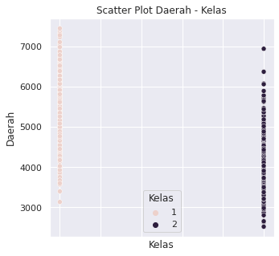

```python
draw_scatter_plot(Gandum["Daerah"], Gandum["Kelas"], Gandum)
```

**Kolom *SumbuUtama***

```python
data1 = Gandum["SumbuUtama"]
data2 = Gandum["Kelas"]
pearson_correlation_test(data1, data2)
```

```
Hipotesis nol ditolak karena nilai t masuk ke dalam critical region.
Nilai t-score yang dihasilkan adalah -22.69848342474694
P-Value yang dihasilkan untuk t-score tersebut adalah 7.742407802528423e-79
```

*Karena $H_{0}$ ditolak, maka berarti bahwa kolom `SumbuUtama` memiliki korelasi dengan kolom `Kelas`. Karena pengujian dilakukan dengan menggunakan `Two-Tailed Test` dan nilai dari t-score masuk ke dalam daerah kritis pada `Left-Tail`, maka kita dapat menduga bahwa korelasi yang dimiliki antara kedua kolom tersebut merupakan korelasi linear berbanding terbalik. Hal ini dapat dilihat pada visualisasi kedua data pada `Scatter Plot` berikut.*

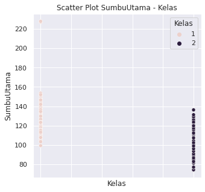

```python
draw_scatter_plot(Gandum["SumbuUtama"], Gandum["Kelas"], Gandum)
```

**Kolom *SumbuKecil***

```python
data1 = Gandum["SumbuKecil"]
data2 = Gandum["Kelas"]
pearson_correlation_test(data1, data2)
```

```
Hipotesis nol ditolak karena nilai t masuk ke dalam critical region.
Nilai t-score yang dihasilkan adalah -3.4544393930005657
P-Value yang dihasilkan untuk t-score tersebut adalah 0.0005985078116774393
```

*Karena $H_{0}$ ditolak, maka berarti bahwa kolom `SumbuKecil` memiliki korelasi dengan kolom `Kelas`. Karena pengujian dilakukan dengan menggunakan `Two-Tailed Test` dan nilai dari t-score masuk ke dalam daerah kritis pada `Left-Tail`, maka kita dapat menduga bahwa korelasi yang dimiliki antara kedua kolom tersebut merupakan korelasi linear berbanding terbalik. Hal ini dapat dilihat pada visualisasi kedua data pada `Scatter Plot` berikut.*

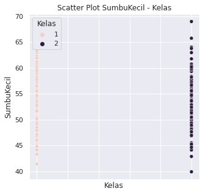

```python
draw_scatter_plot(Gandum["SumbuKecil"], Gandum["Kelas"], Gandum)
```

**Kolom *Keunikan***

```python
data1 = Gandum["Keunikan"]
data2 = Gandum["Kelas"]
pearson_correlation_test(data1, data2)
```

```
Hipotesis nol ditolak karena nilai t masuk ke dalam critical region.
Nilai t-score yang dihasilkan adalah -23.86789326422852
P-Value yang dihasilkan untuk t-score tersebut adalah 1.6496790875484303e-84
```

*Karena $H_{0}$ ditolak, maka berarti bahwa kolom `Keunikan` memiliki korelasi dengan kolom `Kelas`. Karena pengujian dilakukan dengan menggunakan `Two-Tailed Test` dan nilai dari t-score masuk ke dalam daerah kritis pada `Left-Tail`, maka kita dapat menduga bahwa korelasi yang dimiliki antara kedua kolom tersebut merupakan korelasi linear berbanding terbalik. Hal ini dapat dilihat pada visualisasi kedua data pada `Scatter Plot` berikut.*

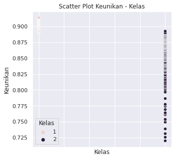

```python
draw_scatter_plot(Gandum["Keunikan"], Gandum["Kelas"], Gandum)
```

**Kolom *AreaBulatan***

```python
data1 = Gandum["AreaBulatan"]
data2 = Gandum["Kelas"]
pearson_correlation_test(data1, data2)
```

```
Hipotesis nol ditolak karena nilai t masuk ke dalam critical region.
Nilai t-score yang dihasilkan adalah -17.05898710873772
P-Value yang dihasilkan untuk t-score tersebut adalah 1.0113804362935853e-51
```

*Karena $H_{0}$ ditolak, maka berarti bahwa kolom `AreaBulatan` memiliki korelasi dengan kolom `Kelas`. Karena pengujian dilakukan dengan menggunakan `Two-Tailed Test` dan nilai dari t-score masuk ke dalam daerah kritis pada `Left-Tail`, maka kita dapat menduga bahwa korelasi yang dimiliki antara kedua kolom tersebut merupakan korelasi linear berbanding terbalik. Hal ini dapat dilihat pada visualisasi kedua data pada `Scatter Plot` berikut.*

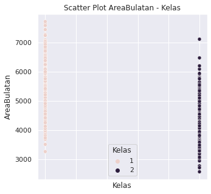

```python
draw_scatter_plot(Gandum["AreaBulatan"], Gandum["Kelas"], Gandum)
```

**Kolom *Diameter***

```python
data1 = Gandum["Diameter"]
data2 = Gandum["Kelas"]
pearson_correlation_test(data1, data2)
```

```
Hipotesis nol ditolak karena nilai t masuk ke dalam critical region.
Nilai t-score yang dihasilkan adalah -16.84785140830175
P-Value yang dihasilkan untuk t-score tersebut adalah 9.862113990159727e-51
```

*Karena $H_{0}$ ditolak, maka berarti bahwa kolom `Diameter` memiliki korelasi dengan kolom `Kelas`. Karena pengujian dilakukan dengan menggunakan `Two-Tailed Test` dan nilai dari t-score masuk ke dalam daerah kritis pada `Left-Tail`, maka kita dapat menduga bahwa korelasi yang dimiliki antara kedua kolom tersebut merupakan korelasi linear berbanding terbalik. Hal ini dapat dilihat pada visualisasi kedua data pada `Scatter Plot` berikut.*

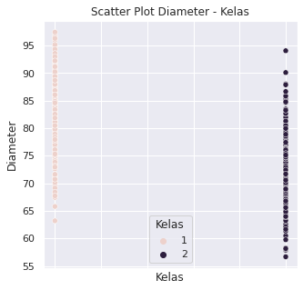

```python
draw_scatter_plot(Gandum["Diameter"], Gandum["Kelas"], Gandum)
```

**Kolom *KadarAir***

```python
data1 = Gandum["KadarAir"]
data2 = Gandum["Kelas"]
pearson_correlation_test(data1, data2)
```

```
Hipotesis nol ditolak karena nilai t masuk ke dalam critical region.
Nilai t-score yang dihasilkan adalah 3.0254405933582365
P-Value yang dihasilkan untuk t-score tersebut adalah 0.002611048361291886
```

*Karena $H_{0}$ ditolak, maka berarti bahwa kolom `KadarAir` memiliki korelasi dengan kolom `Kelas`. Karena pengujian dilakukan dengan menggunakan `Two-Tailed Test` dan nilai dari t-score masuk ke dalam daerah kritis pada `Right-Tail`, maka kita dapat menduga bahwa korelasi yang dimiliki antara kedua kolom tersebut merupakan korelasi linear berbanding lurus. Hal ini dapat dilihat pada visualisasi kedua data pada `Scatter Plot` berikut.*

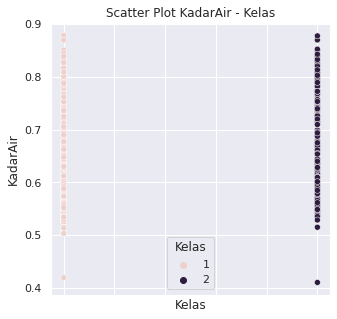

```python
draw_scatter_plot(Gandum["KadarAir"], Gandum["Kelas"], Gandum)
```

**Kolom *Keliling***

```python
data1 = Gandum["Keliling"]
data2 = Gandum["Kelas"]
pearson_correlation_test(data1, data2)
```

```
Hipotesis nol ditolak karena nilai t masuk ke dalam critical region.
Nilai t-score yang dihasilkan adalah -18.336797999269574
P-Value yang dihasilkan untuk t-score tersebut adalah 9.078940431306299e-58
```

*Karena $H_{0}$ ditolak, maka berarti bahwa kolom `Keliling` memiliki korelasi dengan kolom `Kelas`. Karena pengujian dilakukan dengan menggunakan `Two-Tailed Test` dan nilai dari t-score masuk ke dalam daerah kritis pada `Left-Tail`, maka kita dapat menduga bahwa korelasi yang dimiliki antara kedua kolom tersebut merupakan korelasi linear berbanding terbalik. Hal ini dapat dilihat pada visualisasi kedua data pada `Scatter Plot` berikut.*

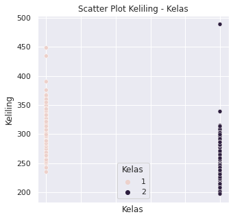

```python
draw_scatter_plot(Gandum["Keliling"], Gandum["Kelas"], Gandum)
```

**Kolom *Bulatan***

```python
data1 = Gandum["Bulatan"]
data2 = Gandum["Kelas"]
pearson_correlation_test(data1, data2)
```

```
Hipotesis nol ditolak karena nilai t masuk ke dalam critical region.
Nilai t-score yang dihasilkan adalah 14.505956489527223
P-Value yang dihasilkan untuk t-score tersebut adalah 5.034375715560436e-40
```

*Karena $H_{0}$ ditolak, maka berarti bahwa kolom `Bulatan` memiliki korelasi dengan kolom `Kelas`. Karena pengujian dilakukan dengan menggunakan `Two-Tailed Test` dan nilai dari t-score masuk ke dalam daerah kritis pada `Right-Tail`, maka kita dapat menduga bahwa korelasi yang dimiliki antara kedua kolom tersebut merupakan korelasi linear berbanding lurus. Hal ini dapat dilihat pada visualisasi kedua data pada `Scatter Plot` berikut.*

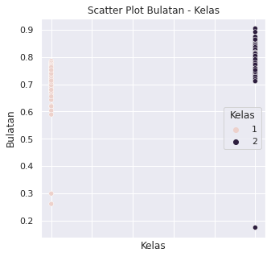

```python
draw_scatter_plot(Gandum["Bulatan"], Gandum["Kelas"], Gandum)
```

**Kolom *Ransum***

```python
data1 = Gandum["Ransum"]
data2 = Gandum["Kelas"]
pearson_correlation_test(data1, data2)
```

```
Hipotesis nol ditolak karena nilai t masuk ke dalam critical region.
Nilai t-score yang dihasilkan adalah -34.53474607283391
P-Value yang dihasilkan untuk t-score tersebut adalah 2.840094086786777e-134
```

*Karena $H_{0}$ ditolak, maka berarti bahwa kolom `Ransum` memiliki korelasi dengan kolom `Kelas`. Karena pengujian dilakukan dengan menggunakan `Two-Tailed Test` dan nilai dari t-score masuk ke dalam daerah kritis pada `Left-Tail`, maka kita dapat menduga bahwa korelasi yang dimiliki antara kedua kolom tersebut merupakan korelasi linear berbanding terbalik. Hal ini dapat dilihat pada visualisasi kedua data pada `Scatter Plot` berikut.*

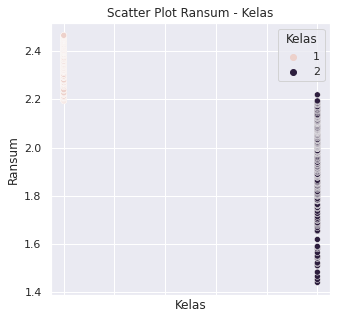

```python
draw_scatter_plot(Gandum["Ransum"], Gandum["Kelas"], Gandum)
```

# Referensi

[Analytics Vidhya](https://www.analyticsvidhya.com/blog/2020/06/statistics-analytics-hypothesis-testing-z-test-t-test/)

[Organic Chemistry](https://www.youtube.com/watch?v=76VruarGn2Q)

[Stikpet](https://www.youtube.com/watch?v=TRNaMGkdn-A)

[TDS1](https://towardsdatascience.com/hypothesis-testing-in-machine-learning-using-python-a0dc89e169ce)

[TDS2](https://towardsdatascience.com/statistical-tests-when-to-use-which-704557554740)